# Liempieza de datos

# Limpieza de texto

Uno de los procesos más difíciles cuando tratamos de texto es la limpieza de los datos. Existen varios tipos de datos para almacenar texto: * **String**: Puede almacenar cadenas, vectores de caracteres. * **Corpus**: Contiene4 cadenas con metadatos y detalles adicionales. * **Document-term matrix**: Es una matriz que describe documentos, donde cada fila representa un documento y cada columna un término. El valor de la matriz es la cantidad de veces que están esos términos en los documentos. * **Tidy text**: Hace más fácil y efectivo el tratamiento de texto. Es una tabla con un token por fila.

Normalmente los pasos para tratar el texto son: * Llevar el texto a un formato fácil de manipular * Seleccionar los tokens del texto * Resumir el texto * Visualizarlo

Por ejemplo, construyamos un vector de caracteres

```r
text <- c("Todos somos aficionados. La vida es tan corta que no da para más.", "Si no sueltas el pasado, ¿con qué mano agarras el futuro?", "Para ser feliz hay que vivir en guerra con las propias pasiones y en paz con las de los demás.", "¿Amas la vida? Pues no desperdicies el tiempo, porque es la sustancia de la que está hecho", "Hay dos maneras de vivir la vida: una como si nada fuese un milagro, la otra como si todo fuese un milagro.")

length(text)
```

```
## [1] 5
```

## Frecuencia de palabras (Función unnest_tokens)

```r
if (!require(tibble)) install.packages("tibble")
library(tibble)
library(tidyverse)
```

Llevar el texto a un dataframe (tibble). Tibble es un tipo de dataframe más fácil de manipular que los dataframe comunes, por bibliotecas como tidyverse:

```r
text_df <- tibble(line = 1:length(text), text = text)
text_df
```

```
## # A tibble: 5 x 2
##    line text
##   <int> <chr>
## 1     1 Todos somos aficionados. La vida es tan corta que no da para más.
## 2     2 Si no sueltas el pasado, ¿con qué mano agarras el futuro?
## 3     3 Para ser feliz hay que vivir en guerra con las propias pasiones y ~
## 4     4 ¿Amas la vida? Pues no desperdicies el tiempo, porque es la sustan~
## 5     5 Hay dos maneras de vivir la vida: una como si nada fuese un milagr~
```

```r
if (!require(tidytext)) install.packages("tidytext")
library(tidytext)
library(tidyverse)
```

### La función **unnest_tokens(dataframe, output, input, token, format, …)**

**output**: columna a ser creada **input**: columna a dividir **token**: “words” (default), “characters”, “character_shingles”, “ngrams”, “skip_ngrams”, “sentences”, “lines”, “paragraphs”, “regex”, “tweets” (tokenization by word that preserves usernames, hashtags, and URLS ), and “ptb” (Penn Treebank) **format**: “text”, “man”, “latex”, “html”, or “xml” **to_lower**: llevar a minúsculas, por defecto está TRUE

Esta función permite separar un texto en palabras(por defecto), líneas, párrafos, o incluso en ngrams.

```r
tokens<-text_df %>%
  unnest_tokens(word, text)

length(tokens$line)
```

```
## [1] 83
```

Separando por sentencia

```r
text_df %>%
  unnest_tokens(word, text, token = "sentences")
```

```
## # A tibble: 7 x 2
##    line word
##   <int> <chr>
## 1     1 todos somos aficionados.
## 2     1 la vida es tan corta que no da para más.
## 3     2 si no sueltas el pasado, ¿con qué mano agarras el futuro?
## 4     3 para ser feliz hay que vivir en guerra con las propias pasiones y ~
## 5     4 ¿amas la vida?
## 6     4 pues no desperdicies el tiempo, porque es la sustancia de la que e~
## 7     5 hay dos maneras de vivir la vida: una como si nada fuese un milagr~
```

```r
temp<-text_df %>%
  unnest_tokens(word, text, token = "ngrams")
length(temp$line)
```

```
## [1] 73
```

```r
temp
```

```
## # A tibble: 73 x 2
##     line word
##    <int> <chr>
##  1     1 todos somos aficionados
##  2     1 somos aficionados la
##  3     1 aficionados la vida
##  4     1 la vida es
##  5     1 vida es tan
##  6     1 es tan corta
##  7     1 tan corta que
##  8     1 corta que no
##  9     1 que no da
## 10     1 no da para
## # ... with 63 more rows
```

## Hacer un worldcloud

```r
if (!require(wordcloud2)) {install.packages("wordcloud2")}
library(wordcloud2)
```

```r
countWord<-tokens %>% count(word,sort = TRUE)
```

```r
wordcloud2(countWord)
```

[interactive chart not shown]

## Ver correlación de palabras

Calculemos los bigramas (contar aparición de dos palabras seguidas)

```r
bigram_text <- text_df%>%
  unnest_tokens(bigram, text, token = "ngrams", n = 2)

bigram_text
```

```
## # A tibble: 78 x 2
##     line bigram
##    <int> <chr>
##  1     1 todos somos
##  2     1 somos aficionados
##  3     1 aficionados la
##  4     1 la vida
##  5     1 vida es
##  6     1 es tan
##  7     1 tan corta
##  8     1 corta que
##  9     1 que no
## 10     1 no da
## # ... with 68 more rows
```

```r
bigram_count<-bigram_text %>%  count(bigram, sort = TRUE)
bigram_count
```

```
## # A tibble: 72 x 2
##    bigram             n
##    <chr>          <int>
##  1 la vida            3
##  2 como si            2
##  3 con las            2
##  4 fuese un           2
##  5 un milagro         2
##  6 aficionados la     1
##  7 agarras el         1
##  8 amas la            1
##  9 con qué            1
## 10 corta que          1
## # ... with 62 more rows
```

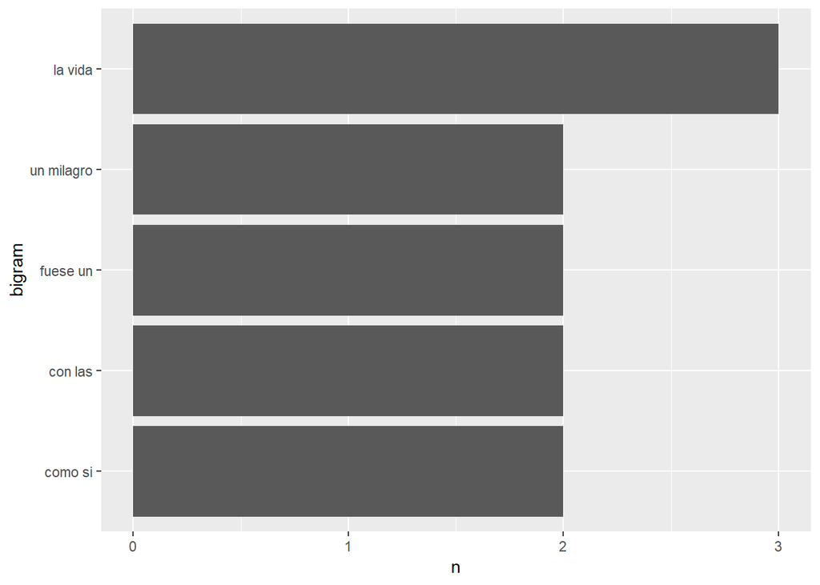

```r
bigram_count %>%
  mutate(bigram=reorder(bigram,n)) %>%
  #filter(n>1) %>%
  top_n(5) %>%
  ggplot(aes(bigram, n)) +
  geom_col() +
  coord_flip()
```

#### Visualizar bigramas con igraph

Separando el bigram en dos columnas

```r
bigram_count<-bigram_count%>% separate(bigram, c("bigram1","bigram2"), sep = " " )
```

```r
if(!require(igraph)) install.packages("igraph")
library(igraph)
```

```r
bigram_graph <- bigram_count %>%
 # filter(n > 20) %>%
  graph_from_data_frame()

bigram_graph
```

```
## IGRAPH fe2b53c DN-- 54 72 --
## + attr: name (v/c), n (e/n)
## + edges from fe2b53c (vertex names):
##  [1] la          ->vida    como        ->si      con         ->las
##  [4] fuese       ->un      un          ->milagro aficionados ->la
##  [7] agarras     ->el      amas        ->la      con         ->qué
## [10] corta       ->que     da          ->para    de          ->la
## [13] de          ->los     de          ->vivir   desperdicies->el
## [16] dos         ->maneras el          ->futuro  el          ->pasado
## [19] el          ->tiempo  en          ->guerra  en          ->paz
## [22] es          ->la      es          ->tan     está        ->hecho
## + ... omitted several edges
```

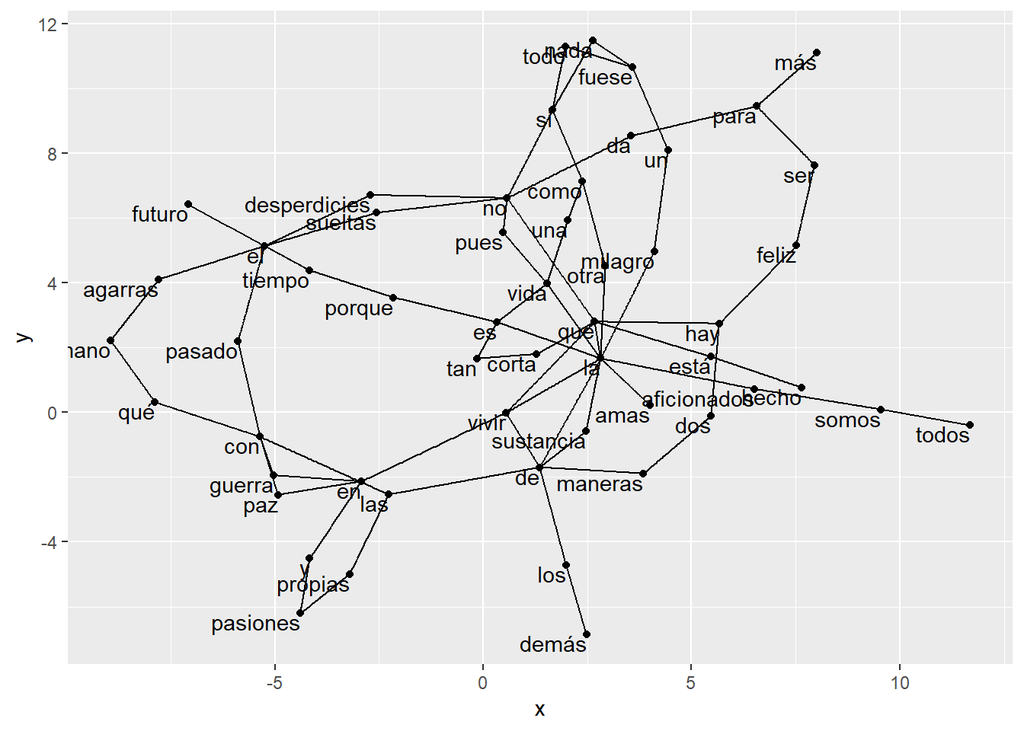

```r
if(!require(ggraph)) install.packages("ggraph")
library(ggraph)
set.seed(2017)

ggraph(bigram_graph, layout = "fr") +
  geom_edge_link() +
  geom_node_point() +
  geom_node_text(aes(label = name), vjust = 1, hjust = 1)
```

## Quitar stop-words

Un stop_words es un conjunto de palabras que se repiten mucho en un idioma, pero no le dan significado real al contenido del texto, como los artículos, preprociones, e inclusyo algunos verbos auxiliares.

Uno puede crear su propio stop_word, por ejemplo:

```r
myStopwords <- c("el","la","que","de", "las", "hay")
myStopwords
```

```
## [1] "el"  "la"  "que" "de"  "las" "hay"
```

```r
tokens_clean <- tokens %>% filter(!word %in% myStopwords)
```

Volvamos a crear el wordcloud

```r
w<-tokens_clean %>% count(word,sort = TRUE)
wordcloud2::wordcloud2(w)
```

[interactive chart not shown]

Hay datos de stop_words en inglés, como el que trae el paquete tidytext.

```r
data(stop_words)
```

Para eliminar los stop_words se puede usar, como hemos visto, la función filter, o se puede utilizar la función **anti_join** también, si usamos la base stop_words:

```r
tokens %>% anti_join(stop_words) %>% count(word,sort = TRUE) %>% wordcloud2()
```

[interactive chart not shown]

Hay también stop_words en español y otros lenguajes. El paquete **tm** tiene en varios idiomas, incluyendo el español.

```r
if (!require(tm)) install.packages("tm")
stop_words_spanish<-stopwords(kind = "spanish")
stop_words_spanish
```

```
##   [1] "de"           "la"           "que"          "el"
##   [5] "en"           "y"            "a"            "los"
##   [9] "del"          "se"           "las"          "por"
##  [13] "un"           "para"         "con"          "no"
##  [17] "una"          "su"           "al"           "lo"
##  [21] "como"         "más"          "pero"         "sus"
##  [25] "le"           "ya"           "o"            "este"
##  [29] "sí"           "porque"       "esta"         "entre"
##  [33] "cuando"       "muy"          "sin"          "sobre"
##  [37] "también"      "me"           "hasta"        "hay"
##  [41] "donde"        "quien"        "desde"        "todo"
##  [45] "nos"          "durante"      "todos"        "uno"
##  [49] "les"          "ni"           "contra"       "otros"
##  [53] "ese"          "eso"          "ante"         "ellos"
##  [57] "e"            "esto"         "mí"           "antes"
```

[output cut: 62 more lines]

Apliquémoslo y creemos el wordcloud

```r
tokens %>% filter(!word %in% stop_words_spanish) %>% count(word,sort = TRUE) %>% wordcloud2()
```

[interactive chart not shown]

También se puede añadir palabras a la base de stop_word

```r
myStopwords <- c(stopwords("spanish"),"si","pues")
myStopwords
```

```
##   [1] "de"           "la"           "que"          "el"
##   [5] "en"           "y"            "a"            "los"
##   [9] "del"          "se"           "las"          "por"
##  [13] "un"           "para"         "con"          "no"
##  [17] "una"          "su"           "al"           "lo"
##  [21] "como"         "más"          "pero"         "sus"
##  [25] "le"           "ya"           "o"            "este"
##  [29] "sí"           "porque"       "esta"         "entre"
##  [33] "cuando"       "muy"          "sin"          "sobre"
##  [37] "también"      "me"           "hasta"        "hay"
##  [41] "donde"        "quien"        "desde"        "todo"
##  [45] "nos"          "durante"      "todos"        "uno"
##  [49] "les"          "ni"           "contra"       "otros"
##  [53] "ese"          "eso"          "ante"         "ellos"
##  [57] "e"            "esto"         "mí"           "antes"
```

[output cut: 63 more lines]

```r
tokens %>% filter(!word %in% myStopwords) %>% count(word,sort = TRUE) %>% wordcloud2()
```

[interactive chart not shown]

Podemos usar también la base que trae tidytext de stop_words

```r
sw<-get_stopwords("es", "snowball")
sw
```

```
## # A tibble: 308 x 2
##    word  lexicon
##    <chr> <chr>
##  1 de    snowball
##  2 la    snowball
##  3 que   snowball
##  4 el    snowball
##  5 en    snowball
##  6 y     snowball
##  7 a     snowball
##  8 los   snowball
##  9 del   snowball
## 10 se    snowball
## # ... with 298 more rows
```

```r
w<-tokens %>% anti_join(get_stopwords("es", "snowball"), by="word") %>% count(word,sort = TRUE) %>% wordcloud2::wordcloud2()
w
```

[interactive chart not shown]

Mostrando en un gráfico de barras las palabras que más se repiten

```r
temp<-tokens %>% anti_join(get_stopwords("es", "snowball"), by="word") %>% count(word,sort = TRUE)
```

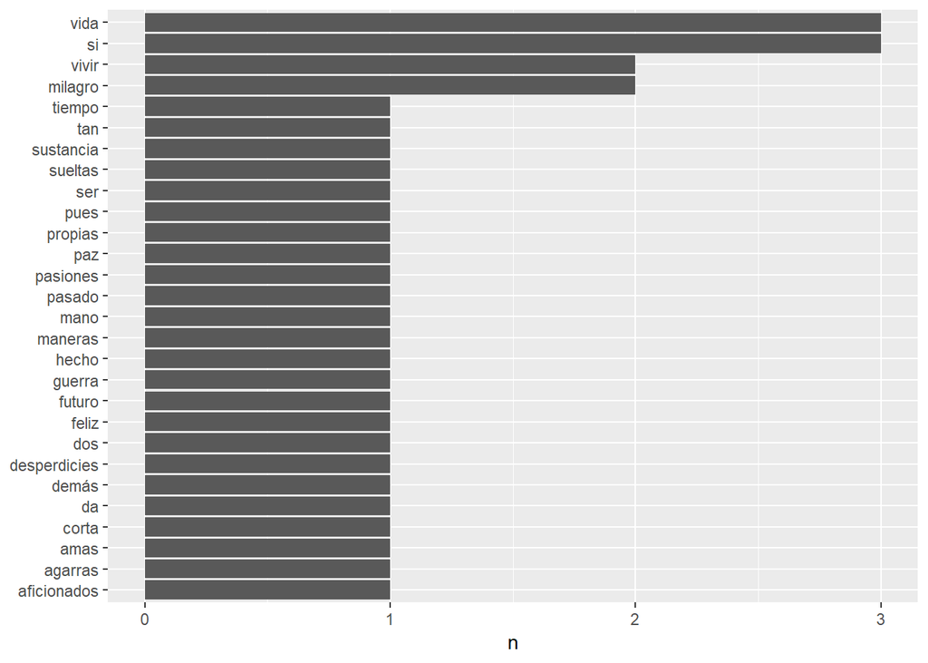

```r
temp %>%
  mutate(word=reorder(word,n)) %>%
  #filter(n>1) %>%
  #top_n(3) %>%
  ggplot(aes(word, n)) +
  geom_col() +
  xlab(NULL) +
  coord_flip()
```

## Frecuencia de palabra y documentos

Una pregunta típica es ¿De qué trata ese documentos o texto?  
Una medida de cuán importante es una palabra en un documento puede ser la frecuencia de ella, como la hemos medido hasta ahora. A esto se le conoce como *term frequency (tf)*.  
Es posible que una palabra sea más importante en un documentos que en otro, cuando estamos analizando varios documentos.  
La técnica de stop-words es buena para eliminar las palabras comunmente usadas en un lenguaje. Otra técnica superior a ésta, cuando trabajamos con diferentes documentos, es la conocida como frecuencia inversa de documentos (idf), que disminuye el peso para palabras comunes y le da mayor peso a las que no son comunmente usadas en una colección de documentos (colección de novelas, o colección de sitios web).

$$idf(término)=ln \left(\frac{n(documentos)}{n(domentos\;con\;término)}\right)$$
Pero el término que nos va a dar la importancia de los términos en un documento que hace parte de una colección es el tf_if, que viene incluido en la biblioteca tidytext.

## Ejemplo usando textos de la novela de Jane Austen

(Tomado del libro: Julia Silge and David Robinson. Text Mining with R)

```r
library(janeaustenr)
original_books <- austen_books()
```

```r
library(stringr)
library(tidytext)
library(tidyverse)
```

Cantidad de frecuencia de palabras por libro.

```r
book_words <- original_books %>%
  unnest_tokens(word, text)%>%
  count(book, word, sort = TRUE)
```

Cantidad total de palabras por libro.

```r
total_words <- book_words %>%
  group_by(book) %>%
  summarize(total = sum(n))
```

```r
book_words <- left_join(book_words, total_words)
```

La función **bind_tf_idf** permite hacer el cálculo de tf, idf y una combinación de los dos

```r
book_words <- book_words %>%
  bind_tf_idf(word, book, n)
book_words
```

```
## # A tibble: 40,379 x 7
##    book              word      n  total     tf   idf tf_idf
##    <fct>             <chr> <int>  <int>  <dbl> <dbl>  <dbl>
##  1 Mansfield Park    the    6206 160460 0.0387     0      0
##  2 Mansfield Park    to     5475 160460 0.0341     0      0
##  3 Mansfield Park    and    5438 160460 0.0339     0      0
##  4 Emma              to     5239 160996 0.0325     0      0
##  5 Emma              the    5201 160996 0.0323     0      0
##  6 Emma              and    4896 160996 0.0304     0      0
##  7 Mansfield Park    of     4778 160460 0.0298     0      0
##  8 Pride & Prejudice the    4331 122204 0.0354     0      0
##  9 Emma              of     4291 160996 0.0267     0      0
## 10 Pride & Prejudice to     4162 122204 0.0341     0      0
## # ... with 40,369 more rows
```

Términos con mayor tf-idf

```r
book_words %>%
  select(-total) %>%
  arrange(desc(tf_idf))
```

```
## # A tibble: 40,379 x 6
##    book                word          n      tf   idf  tf_idf
##    <fct>               <chr>     <int>   <dbl> <dbl>   <dbl>
##  1 Sense & Sensibility elinor      623 0.00519  1.79 0.00931
##  2 Sense & Sensibility marianne    492 0.00410  1.79 0.00735
##  3 Mansfield Park      crawford    493 0.00307  1.79 0.00551
##  4 Pride & Prejudice   darcy       373 0.00305  1.79 0.00547
##  5 Persuasion          elliot      254 0.00304  1.79 0.00544
##  6 Emma                emma        786 0.00488  1.10 0.00536
##  7 Northanger Abbey    tilney      196 0.00252  1.79 0.00452
##  8 Emma                weston      389 0.00242  1.79 0.00433
##  9 Pride & Prejudice   bennet      294 0.00241  1.79 0.00431
## 10 Persuasion          wentworth   191 0.00228  1.79 0.00409
## # ... with 40,369 more rows
```

Visualizándolo por novelas:

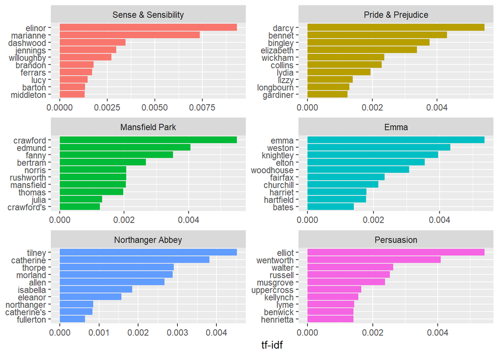

```r
book_words %>%
  arrange(desc(tf_idf)) %>%
  mutate(word = factor(word, levels = rev(unique(word)))) %>%
  group_by(book) %>%
  top_n(10) %>%
  ungroup %>%
  ggplot(aes(word, tf_idf, fill = book)) +
  geom_col(show.legend = FALSE) +
  labs(x = NULL, y = "tf-idf") +
  facet_wrap(~book, ncol = 2, scales = "free") +
  coord_flip()
```

### Adicionar una columna con el número de línea y una con el capítulo al que corresponde

```r
original_books<-original_books %>%
  group_by(book) %>%
  mutate(linenumber = row_number(),
         chapter = cumsum(str_detect(text, regex("^chapter [\\divxlc]",
                                                 ignore_case = TRUE)))) %>%
  ungroup()
```

Dividir en palabras, quitar stop_words y contar la cantidad de palabras

```r
tidy_books <- original_books %>%
  unnest_tokens(word, text)

tidy_books
```

```
## # A tibble: 725,055 x 4
##    book                linenumber chapter word
##    <fct>                    <int>   <int> <chr>
##  1 Sense & Sensibility          1       0 sense
##  2 Sense & Sensibility          1       0 and
##  3 Sense & Sensibility          1       0 sensibility
##  4 Sense & Sensibility          3       0 by
##  5 Sense & Sensibility          3       0 jane
##  6 Sense & Sensibility          3       0 austen
##  7 Sense & Sensibility          5       0 1811
##  8 Sense & Sensibility         10       1 chapter
##  9 Sense & Sensibility         10       1 1
## 10 Sense & Sensibility         13       1 the
## # ... with 725,045 more rows
```

```r
data(stop_words)

tidy_books <- tidy_books %>%
  anti_join(stop_words)
tidy_books %>%
  count(word, sort = TRUE)
```

```
## # A tibble: 13,914 x 2
##    word       n
##    <chr>  <int>
##  1 miss    1855
##  2 time    1337
##  3 fanny    862
##  4 dear     822
##  5 lady     817
##  6 sir      806
##  7 day      797
##  8 emma     787
##  9 sister   727
## 10 house    699
## # ... with 13,904 more rows
```

Graficar palabras más importantes.

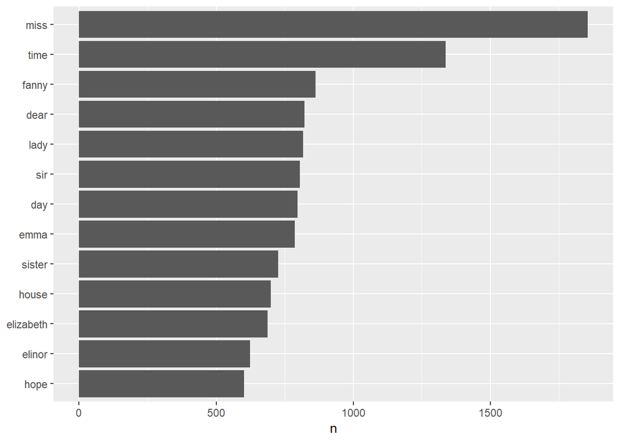

```r
library(ggplot2)

tidy_books %>%
  count(word, sort = TRUE) %>%
  filter(n > 600) %>%
  mutate(word = reorder(word, n)) %>%
  ggplot(aes(word, n)) +
  geom_col() +
  xlab(NULL) +
  coord_flip()
```

Calculando bigram y buscando relación entre ellos.

```r
austen_bigrams <- austen_books() %>%
  unnest_tokens(bigram, text, token = "ngrams", n = 2)
```

Separando los bigramas en dos columans.

```r
bigrams_separated <- austen_bigrams %>%
  separate(bigram, c("word1", "word2"), sep = " ")
```

Quitando los stop_words.

```r
  bigrams_filtered <- bigrams_separated %>%
  filter(!word1 %in% stop_words$word) %>%
  filter(!word2 %in% stop_words$word)
```

Uniendo de nuevo los bigramas en una sola columna, después de quitar los stop_words.

```r
bigrams_united <- bigrams_filtered %>%
  unite(bigram, word1, word2, sep = " ")
```

Calculando tf_idf

```r
bigram_tf_idf <- bigrams_united %>%
  count(book, bigram) %>%
  bind_tf_idf(bigram, book, n) %>%
  arrange(desc(tf_idf))
```

Graficando bigramamas con mayor relevancia (mayor tf_idf) en los diferentes textos.

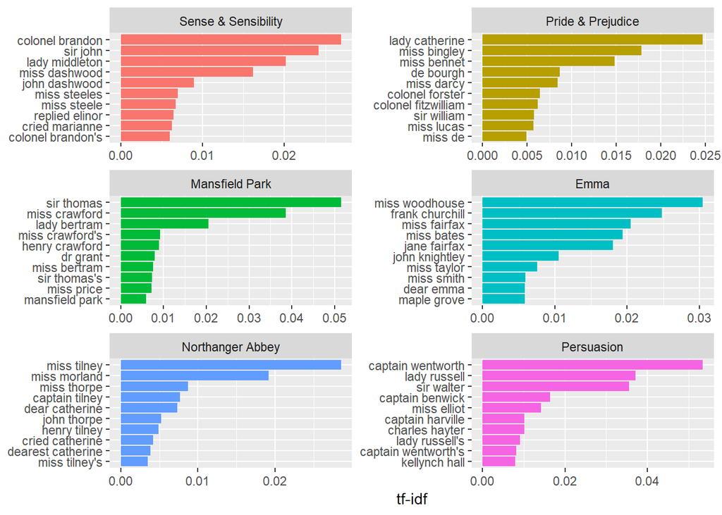

```r
bigram_tf_idf %>%
  arrange(desc(tf_idf)) %>%
  mutate(bigram = factor(bigram, levels = rev(unique(bigram)))) %>%
  group_by(book) %>%
  top_n(10) %>%
  ungroup %>%
  ggplot(aes(bigram, tf_idf, fill = book)) +
  geom_col(show.legend = FALSE) +
  labs(x = NULL, y = "tf-idf") +
  facet_wrap(~book, ncol = 2, scales = "free") +
  coord_flip()
```

#### Visualizar bigram en red de relaciones.

```r
bigram_counts <- bigrams_filtered %>%
  count(word1, word2, sort = TRUE)
```

```r
library(igraph)
bigram_graph <- bigram_counts %>%
  filter(n > 20) %>%
  graph_from_data_frame()
```

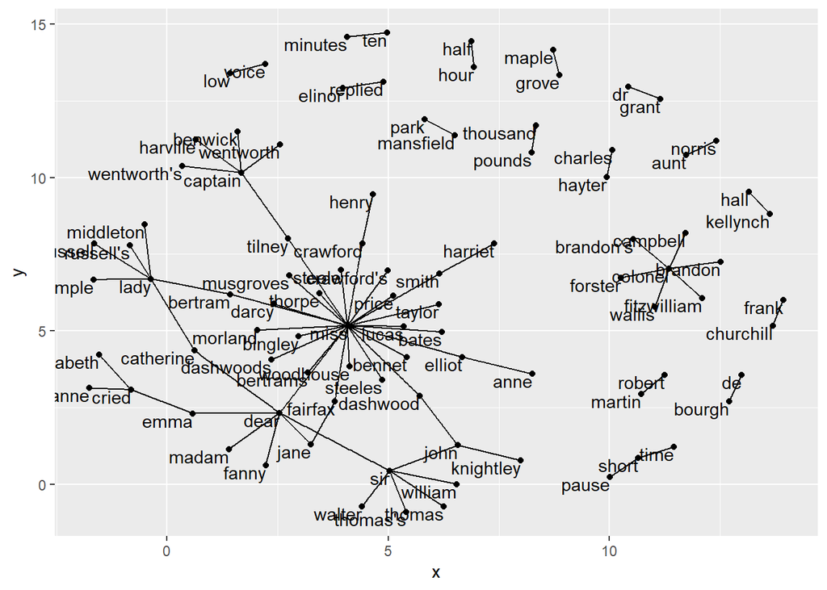

```r
library(ggraph)
set.seed(2)

ggraph(bigram_graph, layout = "fr") +
  geom_edge_link() +
  geom_node_point() +
  geom_node_text(aes(label = name), vjust = 1, hjust = 1)
```

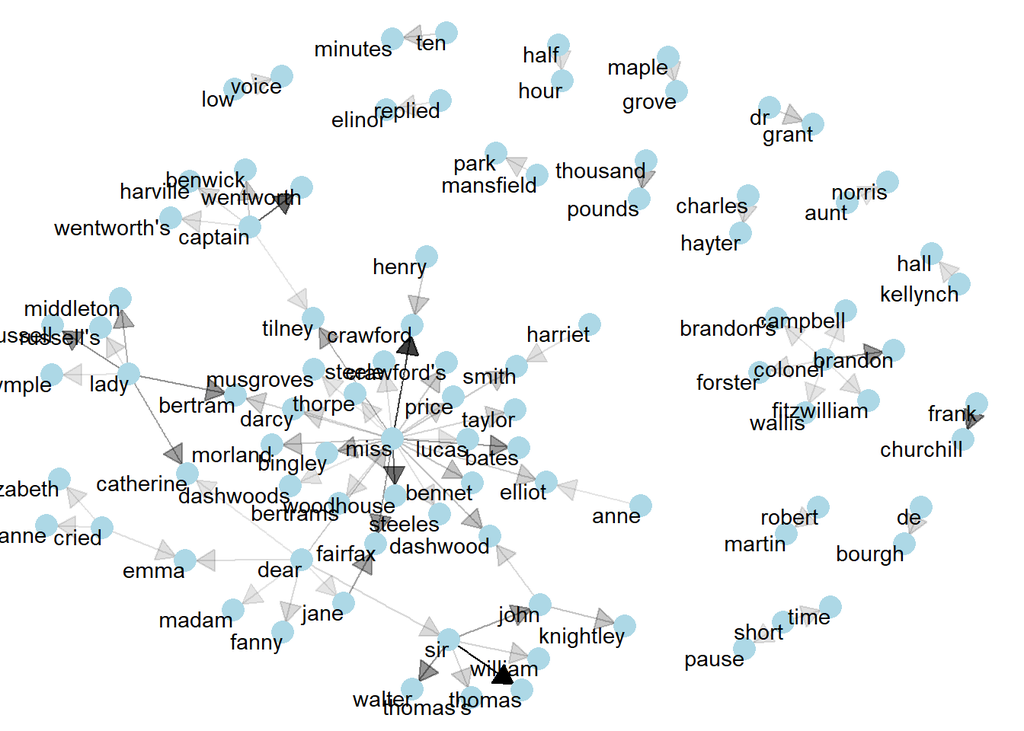

```r
set.seed(2)

a <- grid::arrow(type = "closed", length = unit(.15, "inches"))

ggraph(bigram_graph, layout = "fr") +
  geom_edge_link(aes(edge_alpha = n), show.legend = FALSE,
                 arrow = a, end_cap = circle(.07, 'inches')) +
  geom_node_point(color = "lightblue", size = 5) +
  geom_node_text(aes(label = name), vjust = 1, hjust = 1) +
  theme_void()
```

# Funciones para limpiar texto

La biblioteca **tm** tiene varias funciones útiles a la hora de limpiar texto.

tolower(): convierte a minúsculas removePunctuation(): quita todas las marcas de puntuaciones removeNumbers(): elimina números stripWhitespace(): elimina exceso de espacios en blanco